# R Notebook

1.Explore the overall structure of the dataset using “str” and “summary” functions.

```r
data <- read.csv(file="C:/ml/realtor.csv")
```

```r
str(data)
```

```
'data.frame':   923159 obs. of  12 variables:
 $ status      : chr  "for_sale" "for_sale" "for_sale" "for_sale" ...
 $ price       : num  105000 80000 67000 145000 65000 179000 50000 71600 100000 300000 ...
 $ bed         : num  3 4 2 4 6 4 3 3 2 5 ...
 $ bath        : num  2 2 1 2 2 3 1 2 1 3 ...
 $ acre_lot    : num  0.12 0.08 0.15 0.1 0.05 0.46 0.2 0.08 0.09 7.46 ...
 $ full_address: chr  "Sector Yahuecas Titulo # V84, Adjuntas, PR, 00601" "Km 78 9 Carr # 135, Adjuntas, PR, 00601" "556G 556-G 16 St, Juana Diaz, PR, 00795" "R5 Comunidad El Paraso Calle De Oro R-5 Ponce, Ponce, PR, 00731" ...
 $ street      : chr  "Sector Yahuecas Titulo # V84" "Km 78 9 Carr # 135" "556G 556-G 16 St" "R5 Comunidad El Paraso Calle De Oro R-5 Ponce" ...
 $ city        : chr  "Adjuntas" "Adjuntas" "Juana Diaz" "Ponce" ...
 $ state       : chr  "Puerto Rico" "Puerto Rico" "Puerto Rico" "Puerto Rico" ...
 $ zip_code    : num  601 601 795 731 680 612 639 731 730 670 ...
 $ house_size  : num  920 1527 748 1800 NA ...
 $ sold_date   : chr  "" "" "" "" ...
```

# 12 Variables and 923159 observations is there.

```r
summary(data)
```

```
    status              price                bed              bath           acre_lot
 Length:923159      Min.   :        0   Min.   :  1.00   Min.   :  1.00   Min.   :     0.00
 Class :character   1st Qu.:   269000   1st Qu.:  2.00   1st Qu.:  1.00   1st Qu.:     0.11
 Mode  :character   Median :   475000   Median :  3.00   Median :  2.00   Median :     0.29
                    Mean   :   884123   Mean   :  3.33   Mean   :  2.49   Mean   :    17.08
                    3rd Qu.:   839900   3rd Qu.:  4.00   3rd Qu.:  3.00   3rd Qu.:     1.15
                    Max.   :875000000   Max.   :123.00   Max.   :198.00   Max.   :100000.00
                    NA's   :71          NA's   :131703   NA's   :115192   NA's   :273623
 full_address          street              city              state              zip_code       house_size
 Length:923159      Length:923159      Length:923159      Length:923159      Min.   :  601   Min.   :    100
 Class :character   Class :character   Class :character   Class :character   1st Qu.: 2919   1st Qu.:   1130
 Mode  :character   Mode  :character   Mode  :character   Mode  :character   Median : 7004   Median :   1651
                                                                             Mean   : 6590   Mean   :   2142
                                                                             3rd Qu.:10001   3rd Qu.:   2499
                                                                             Max.   :99999   Max.   :1450112
                                                                             NA's   :205     NA's   :297843
  sold_date
 Length:923159
 Class :character
 Mode  :character
```

2.What is the type of each variable categorical/discrete or numeric/continuous? For categorical/discrete variables, specify whether it is nominal or ordinal.

categorical-status,street,full_address,city,state,sold_date numerical-price,bed,bath,acre_lot,zip_code, house_size

```r
install.packages("tidyverse")
library("tidyverse")
```

3.are there any duplicate observations in the data? If so, remove them. You can use “duplicated” or “unique” functions to answer this question.

```r
duplicated(data)
```

[output not shown]

[output cut: 45 more lines]

#this are duplicated observations.

```r
unique(data)
```

|  | status | price | bed | bath | acre_lot | full_address | street | city | state | zip_code | house_size | sold_date |
| --- | --- | --- | --- | --- | --- | --- | --- | --- | --- | --- | --- | --- |
| 1 | for_sale | 105000 | 3 | 2 | 0.12 | Sector Yahuecas Titulo # V84, Adjuntas, PR, 00601 | Sector Yahuecas Titulo # V84 | Adjuntas | Puerto Rico | 601 | 920 |  |
| 2 | for_sale | 80000 | 4 | 2 | 0.08 | Km 78 9 Carr # 135, Adjuntas, PR, 00601 | Km 78 9 Carr # 135 | Adjuntas | Puerto Rico | 601 | 1527 |  |
| 3 | for_sale | 67000 | 2 | 1 | 0.15 | 556G 556-G 16 St, Juana Diaz, PR, 00795 | 556G 556-G 16 St | Juana Diaz | Puerto Rico | 795 | 748 |  |
| 4 | for_sale | 145000 | 4 | 2 | 0.10 | R5 Comunidad El Paraso Calle De Oro R-5 Ponce, Ponce, PR, 00731 | R5 Comunidad El Paraso Calle De Oro R-5 Ponce | Ponce | Puerto Rico | 731 | 1800 |  |
| 5 | for_sale | 65000 | 6 | 2 | 0.05 | 14 Navarro, Mayaguez, PR, 00680 | 14 Navarro | Mayaguez | Puerto Rico | 680 | NA |  |
| 6 | for_sale | 179000 | 4 | 3 | 0.46 | Bo Calabazas San Sebastian, San Sebastian, PR, 00612 | Bo Calabazas San Sebastian | San Sebastian | Puerto Rico | 612 | 2520 |  |
| 7 | for_sale | 50000 | 3 | 1 | 0.20 | 49.1 140, Ciales, PR, 00639 | 49.1 140 | Ciales | Puerto Rico | 639 | 2040 |  |
| 8 | for_sale | 71600 | 3 | 2 | 0.08 | 3467 St, Ponce, PR, 00731 | 3467 St | Ponce | Puerto Rico | 731 | 1050 |  |
| 9 | for_sale | 100000 | 2 | 1 | 0.09 | 230 Rio De Vida, Ponce, PR, 00730 | 230 Rio De Vida | Ponce | Puerto Rico | 730 | 1092 |  |
| 10 | for_sale | 300000 | 5 | 3 | 7.46 | Pr 120 Bo Maravilla Sur K M # 335, Las Marias, PR, 00670 | Pr 120 Bo Maravilla Sur K M # 335 | Las Marias | Puerto Rico | 670 | 5403 |  |

[output cut: 990 more lines]

```r
library(magrittr)
library(dplyr)
data=data %>% distinct()
```

4.Does any of the variables have missing values? Which ones?

```r
is.na(data)
```

[output not shown]

[output cut: 70 more lines]

```r
IQR <- IQR(data$price,na.rm=TRUE)
```

```r
IQR
```

```
[1] 550000
```

```r
summary(data$price)
```

```
     Min.   1st Qu.    Median      Mean   3rd Qu.      Max.      NA's
        0    250000    449900    909606    800000 875000000        18
```

```r
left <- 250000-1.5*IQR
left
```

```
[1] -575000
```

```r
right <-800000 +1.5*IQR
right
```

```
[1] 1625000
```

```r
x <- data$price
y=x[x<left | x>right]
y
```

[output not shown]

[output cut: 77 more lines]

```r
quantile(data$price,na.rm=TRUE)
```

```
       0%       25%       50%       75%      100%
        0    250000    449900    800000 875000000
```

```r
length(y)
```

```
[1] 11971
```

```r
data$price[(data$price<=50000), drop = FALSE]
```

[output not shown]

[output cut: 45 more lines]

```r
data$price
```

[output not shown]

[output cut: 77 more lines]

7.Draw a histogram and boxplot of the price. What can you say about the shape of price variable? Is the price variable positively skewed, symmetric, or negatively skewed?

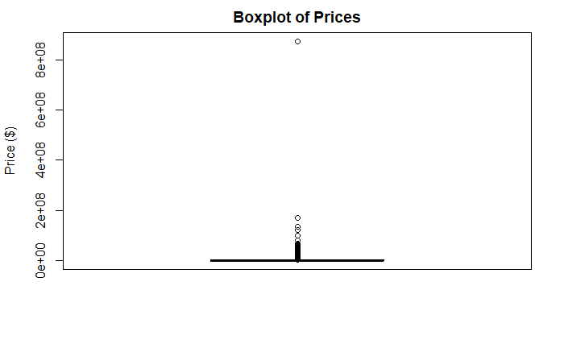

```r
 boxplot(data$price, main="Boxplot of Prices",
ylab="Price ($)")
```

*Many outliers are expensive for their class.

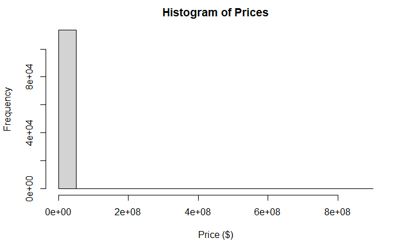

```r
hist(data$price, main = "Histogram of Prices", xlab =
"Price ($)")
```

- The histogram indicates that it is right-skewed.

8.what percentage of the observations are missing for the price variable?

```r
mean(is.na(data$price))*100
```

```
[1] 0.01581875
```

9.Use as.Date method to convert the sold_date variable from character string to date/time type. Then from this date/time object create two new attributes (sold_year) and (sold_month) to store the year and month that the house was sold

```r
sold_date_formatted <- as.Date(data$sold_date, format = "%Y-%m-%d")
sold_date_formatted
```

[output not shown]

[output cut: 111 more lines]

```r
class(sold_date_formatted)
```

```
[1] "Date"
```

```r
sold_date_month <- format(sold_date_formatted, "%m")
sold_date_month
```

[output not shown]

[output cut: 34 more lines]

```r
data$sold_year<- format(sold_date_formatted, "%Y")
data$sold_year
```

[output not shown]

[output cut: 53 more lines]

10.convert the “state” attribute to factor then take a summary to see how many observations are there for each state. Remove states with only one observation from the data.

```r
data$state<-as.factor(data$state)

data$state
```

[output not shown]

[output cut: 112 more lines]

```r
attach(data)
```

```r
summary(data$price)
```

```
     Min.   1st Qu.    Median      Mean   3rd Qu.      Max.      NA's
        0    250000    449900    909606    800000 875000000        18
```

```r
library(dplyr)

data<-data %>% group_by(data$state) %>% filter(n()>1)
```

```r
summary(data$state)
```

```
   Connecticut       Delaware        Georgia          Maine  Massachusetts  New Hampshire     New Jersey
         13839           1298              5           5061          10193           3561          32759
      New York   Pennsylvania    Puerto Rico   Rhode Island South Carolina      Tennessee        Vermont
         28634           9065           2664           3419              0              0           2530
Virgin Islands       Virginia  West Virginia        Wyoming
           750              7              0              0
```

11.Is there a statistically significant difference between the average house price for different states? Use appropriate plot and statistic test to answer this question.

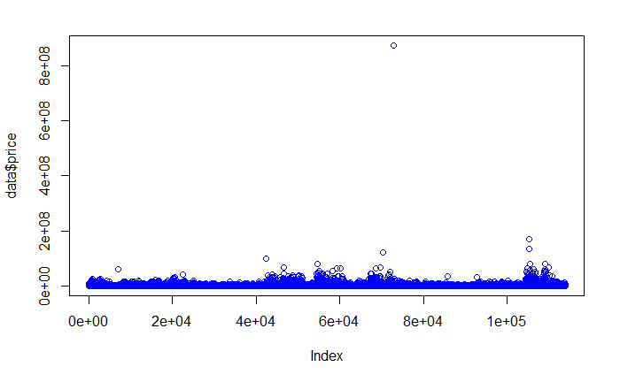

```r
plot( data$price,na.rm=TRUE ~ data$state , col="blue")
```

```r
oneway.test ( data$price ~ data$state, data=data)
```

```
    One-way analysis of means (not assuming equal variances)

data:  data$price and data$state
F = 258.91, num df = 13.00, denom df = 155.05, p-value < 2.2e-16
```

12.What is the correlation between house_price and the variables sold_year, house_size, bed, and bath?

```r
cor(data$price, data$bath, method = 'spearman',use="pairwise.complete.obs" )
```

```
[1] 0.5309176
```

```r
cor.test(data$price, data$bath, method = 'spearman',use="pairwise.complete.obs" )
```

```
    Spearman's rank correlation rho

data:  data$price and data$bath
S = 7.244e+13, p-value < 2.2e-16
alternative hypothesis: true rho is not equal to 0
sample estimates:
      rho
0.5309176
```

```r
cor(data$price, data$house_size, method = 'spearman',use="pairwise.complete.obs" )
```

```
[1] 0.4983486
```

```r
cor.test(data$price, data$house_size, method = 'spearman',use="pairwise.complete.obs" )
```

```
    Spearman's rank correlation rho

data:  data$price and data$house_size
S = 3.8649e+13, p-value < 2.2e-16
alternative hypothesis: true rho is not equal to 0
sample estimates:
      rho
0.4983486
```

```r
cor(data$price, data$bed, method = 'spearman',use="pairwise.complete.obs" )
```

```
[1] 0.285226
```

```r
cor.test(data$price, data$bed, method = 'spearman',use="pairwise.complete.obs" )
```

```
    Spearman's rank correlation rho

data:  data$price and data$bed
S = 1.0623e+14, p-value < 2.2e-16
alternative hypothesis: true rho is not equal to 0
sample estimates:
     rho
0.285226
```

```r
summary(data$sold_year)
```

```
   Length     Class      Mode
   113785 character character
```

```r
cor(data$price, as.numeric(data$sold_year), method = 'spearman',use="pairwise.complete.obs" )
```

```
[1] 0.001745574
```

```r
cor.test(data$price, as.numeric(data$sold_year), method = 'spearman',use="pairwise.complete.obs" )
```

```
    Spearman's rank correlation rho

data:  data$price and as.numeric(data$sold_year)
S = 3.5395e+13, p-value = 0.6698
alternative hypothesis: true rho is not equal to 0
sample estimates:
        rho
0.001745574
```